# R5.01 - Environnement économique : Économie des inégalités

Chapitre 3: définir les différentes formes d’inégalités

Thomas Delcey

thomas.delcey@ube.fr

Université de Bourgogne Europe

### Le problème du chapitre

**Les inégalités, mais de quoi ?**

Le chapitre 2 discutait les arguments en faveur et en défaveur d’une réduction des inégalités. Mais nous sommes restés particulièrement vagues sur ce qui fait l’objet d’une inégalité.

Avant de pouvoir mesurer les inégalités en France, il faut d’abord définir précisément ce que nous cherchons à mesurer. C’est l’objet de ce chapitre.

### Les inégalités économiques

- Il existe deux grandes catégories d’inégalités économiques: les inégalités de **revenus** et les inégalités de **patrimoine**.

**Revenus**

Le revenu est un flux, qui recouvre l’ensemble des flux monétaires perçu par une personne.

**Patrimoine (ou capital)**

Le patrimoine est un stock, qui recouvre l’ensemble des biens et droits possédés par une personne à un instant donné.

### Le revenu

**Important**

Le revenu n’est pas que le salaire.

- Le revenu peut provenir de différentes sources:
  - le travail (salaires, primes, etc.),
  - le patrimoine (intérêts, dividendes, loyers, plus-values, etc.),
  - la redistribution (allocations sociales, pensions, etc.).

**Important**

Le revenu n’est pas un concept univoque. Il existe plusieurs définitions du revenu qui donnent lieu à des perceptions et mesures différentes des inégalités.

### Le revenu dans la comptabilité nationale

**Revenu primaire**

Le **revenu primaire** est le revenu avant redistribution. C’est la somme des revenus du travail et du patrimoine.

**Revenu disponible brut**

Le **revenu disponible brut** est le revenu après redistribution. C’est le revenu primaire plus les prestations sociales moins les impôts directs et cotisations sociales.

**Revenu disponible brut ajusté**

Le **revenu disponible brut ajusté** est le revenu disponible brut plus les prestations en nature (éducation, santé, etc.) qui sont individuellement consommées. On n’inclut pas les services collectifs (sécurité, justice, etc.) qui sont consommés collectivement.

### Revue, impôts et redistribution

[video not shown]

### Le revenu par adulte

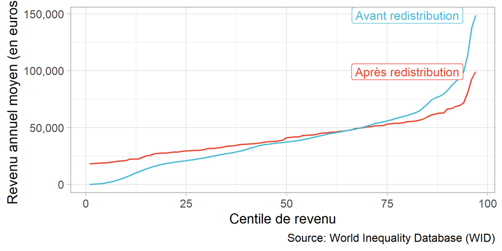

### Le revenu par adulte (avec les 2%)

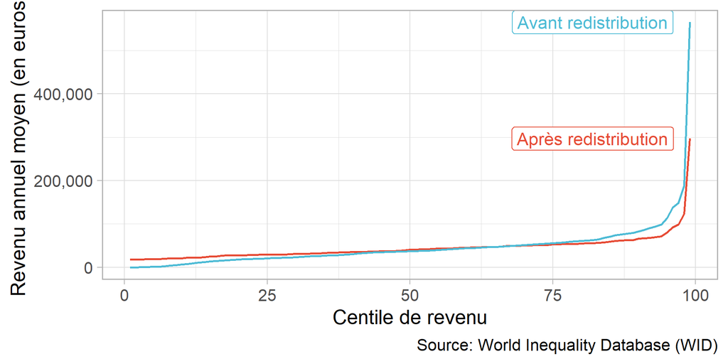

### La composition du revenu des français.es

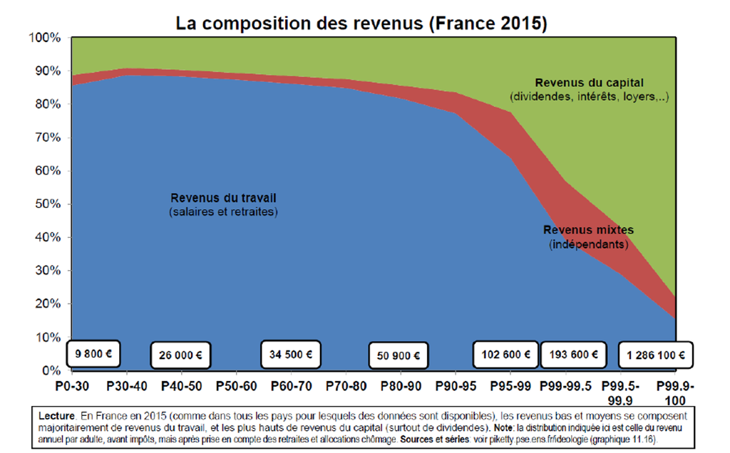

Source: Thomas Piketty (2019). Capital et Idéologie.

### Le patrimoine

- Le patrimoine correspond à la valeur monétaire des propriétés des agents:
  - Biens immobiliers ;
  - Biens mobiliers ou financiers (actions, obligations, comptes bancaires, etc.) ;
  - Biens professionnels (outils de travail, entreprises, etc.) ;
  - Dettes.

Quand on parle des personnes les plus riches au monde, on parle essentiellement de la valeur de leur patrimoine financier.

### La composition du patrimoine des ménages en 2021

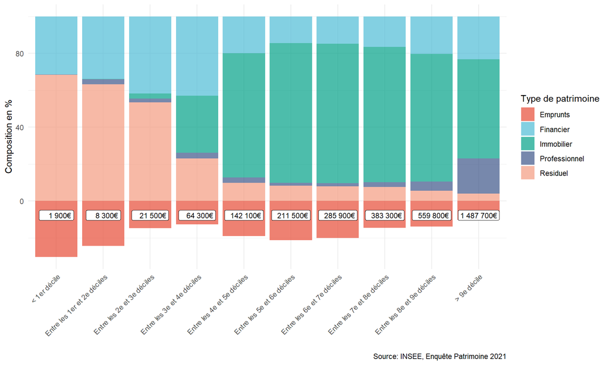

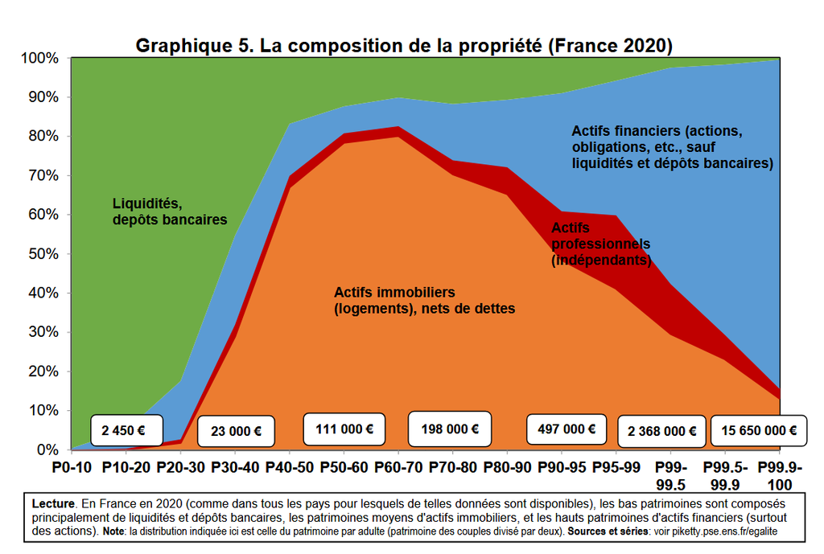

### Au-delà des inégalités économiques

**Quel est le métier des parents qui maximisent les chances de réussite scolaire des enfants ?**

Les **enfants d’enseignant.es** sont sur-représentés dans les meilleurs filières (classes préparatoires, grandes écoles, etc.) ;

- Pourquoi ?
  - Meilleure compréhension du système scolaire ;
  - Adéquation des emplois du temps ;
  - Meilleure pédagogie ;
  - Soutien scolaire à la maison explicite et **implicite** ;

**Mise en garde**

Comment caractériser cette richesse qui n’est pas économique ?

### Les inégalités sociales

- Pierre Bourdieu (1930-2002) a proposé une théorie des inégalités sociales fondée sur la notion de **capital**. Il en distingue trois formes:
  - Le **capital économique** (revenu et patrimoine) ;
  - Le **capital culturel** ;
  - Le **capital social**.

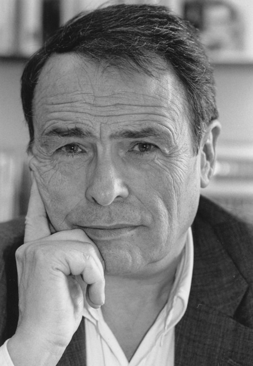

Pierre Bourdieu (1930-2002)

> « La reproduction des inégalités sociales par l’école vient de la mise en œuvre d’un égalitarisme formel, à savoir que l’école traite comme “égaux en droits” des individus “inégaux en fait” c’est-à-dire inégalement préparés par leur culture familiale à assimiler un message pédagogique. »

Bourdieu et Passeron (1970)

[figure not shown]

Pierre Bourdieu (1930-2002)

### Les inégalités ne sont pas qu’économiques

- 🇺🇸 Aux Etats-Unis, les frais moyens de scolarité dans les universités sont de:
  - 9 596 $ par an dans les universités publiques ;
  - 34 041$ dans les universités privées.
- 🇫🇷 En France, les frais moyens d’inscription à l’université sont aux alentours de 200$ par an (pour les français.es) dans les universités publiques.

**Important**

Pourtant, les deux pays ont une mobilité sociale comparable (et plutôt faible) par rapport aux autres pays développés (Corak 2013).

**Important**

La réussite scolaire et la reproduction des inégalités dépend évidemment de facteurs économiques, mais aussi culturels et sociaux.

Source des chiffres: OECD (2025)

### Références

Bourdieu, Pierre, et Jean-Claude Passeron. 1970. *La reproduction: Éléments pour une théorie du système d’enseignement*. Le sens commun. Paris: Éditions de Minuit.

Corak, Miles. 2013. « Income Inequality, Equality of Opportunity, and Intergenerational Mobility ». *Journal of Economic Perspectives* 27 (3): 79‑102. https://doi.org/10.1257/jep.27.3.79.

OECD. 2025. « Education at a Glance 2025: United States ». Organisation for Economic Co-operation and Development (OCDE). https://www.oecd.org/en/publications/education-at-a-glance-2025_1a3543e2-en/united-states_784df67f-en.html.

Piketty, Thomas. 2019. *Capital et idéologie*. Paris: Éditions du Seuil. http://piketty.pse.ens.fr/fr/ideologie.

———. 2021. *Une brève histoire de l’égalité*. Paris: Éditions du Seuil. http://piketty.pse.ens.fr/fr/egalite.